# TADs_primer

The **dataset** is composed of thousands of **30-mer sequences** with their associated number of **reads** in each **bin** from a sorting experiment in **FACS**  
(*seq, bckgnd, bin1, bin2, bin3, bin4*)

**Sequences** were **scored** based on their distribution of reads per bin and a weight that varies between *old-data* and *new-data*.  
**Sequences** were also **labeled** based on the same distribution of reads per bin.

**scores** $\epsilon(0-\infty$)  
**labels** = 1 (TAD) | 0 (no TAD)

The **goal** is to undestand how composition of aminoacids and/or other calculated or predicted physico-chemical properties of the 30mers can characterize a TAD. The analysis is splitted into several steps:

- introduction
- Correlation of single properties with scores or labels
  - amino acid frequencies
  - physicochemical properties
- Correlation of linear combination of properties with scores or labels
- Correlation of linear combination of k-mers with scores or labels
- Non-linear model with XG boosting
- Position preferences
- Deep learning
- Conclussions
- Few Functions
  - split data
  - roc curve
- 1&2 nodes dense

### Introduction

```python
%pylab inline
import seaborn
import scipy, sklearn
import os,sys
from univariate_rocs import *
import warnings
warnings.filterwarnings('ignore')

start, end = "\033[1m", "\033[0;0m" # this is to print bold
print('\n')
for module in ['numpy','scipy','pd','sklearn','matplotlib','seaborn']:
    print(module + ': ' + eval(module).__version__)
```

```
================================================================================
hydroph_df: hydrophobicities per nt
iupred_short, iupred_short: predicted disorder per nt
================================================================================
================================================================================
 Calculate scores based on mean of bins for each FACS sorting
 bins info used in this script should be found in bins_info.py
================================================================================

17009 positives and 17306 negatives makes a 1.0174613439943558 ratio of negat/posit


numpy: 1.14.3
scipy: 1.1.0
pd: 0.23.0
sklearn: 0.19.1
matplotlib: 2.2.2
seaborn: 0.8.1
```

**old & new data** are derived from the same fastq files, except that different filter cutoffs where applied. New data sequences were cluster together while old data clustering was applied to each experiment (different bins) separately $\bf{^{1}}$. There are **75846** sequences in the new data ($\frac{1}{2}$ positives and negatives) and **62395** in the old data used for regression. Old data for classificaton has 17009 positives and 17306 negatives samples.  
Old_regression and New data share only **36361** sequences.  
Old data is composed of two different groups, regression (with a score per sequence) and classification (with a label 'TAD' that could take values 0 or 1).  
All sequences are **30 residues long**.

**1**. Clastering is done to avoid including variants of the same original sequence, originated during DNA handling (pcr and sequencing errors). Usearch was used.

```
old_data: ['scores']
old_data: ['TAD']
new_data: ['scores', 'norm_scores', 'TAD']
```

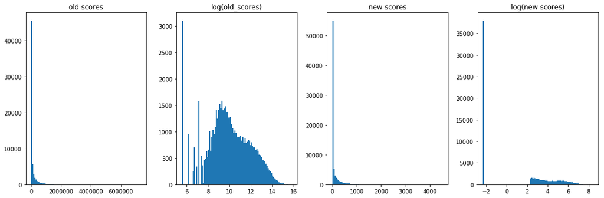

```python
# old data
old_data_regress = pd.DataFrame(y_tad_regress)
old_data_classif = pd.DataFrame(y_tad_classif)

# new data
positives = open_fastas('/fh/scratch/delete10/hahn_s/aerijman/2018_data'+
                        '/ARG3_O1_O2_clustered_rescored.fasta_bin14_threshold10.0_37923positives.fasta')

negatives = open_fastas('/fh/scratch/delete10/hahn_s/aerijman/2018_data'+
                        '/ARG3_O1_O2_clustered_rescored.fasta_bg_37923negatives.fasta')

positives['TAD']=1
negatives['TAD']=0

new_data = pd.concat([pd.DataFrame(i) for i in [positives, negatives]], axis=0)

print('old_data: {}'.format(list(old_data_regress.columns)))
print('old_data: {}'.format(list(old_data_classif.columns)))
print('new_data: {}'.format(list(new_data.columns)))


plt.figure(figsize=(15,5))
datas = {'old scores': old_data_regress.scores,
             'log(old_scores)': np.log(old_data_regress.scores+0.1),
             'new scores': new_data.scores,
             'log(new scores)': np.log(new_data.scores+0.1)}

for n, (name, data) in enumerate(datas.items()):
    plt.subplot(1,4,n+1)
    plt.hist(data, bins=100)
    plt.title(name)

plt.tight_layout()
```

Applying logarithm, I transform the scores from folloing an exponential decay to a more normal distribution to be used in linear models with not too many variables. The new data has all negative samples scored 0 and positive samples start with 10.

## Single properties

### Amino-acid frequencies

```python
# scores follow a
old_data_regress['log_scores'] = np.log(old_data_regress['scores'] +0.1)
new_data['log_scores'] = np.log(new_data['scores']+0.1)

# list of one-letter aa
aa = ['R','H','K','D','E','S','T','N','Q','A','V','L','I','M','F' ,'Y', 'W', 'C','G','P']

# calculate aa frequencies per sample.
for i in aa:
    old_data_regress[i] = [seq.count(i) / 30. for seq in old_data_regress.index]
    old_data_classif[i] = [seq.count(i) / 30. for seq in old_data_classif.index]
    new_data[i] = [seq.count(i) / 30. for seq in new_data.index]

old_data_regress.iloc[:5,:10] # Printing part of the columns is more clear to me...
```

|  | scores | log_scores | R | H | K | D | E | S | T | N |
| --- | --- | --- | --- | --- | --- | --- | --- | --- | --- | --- |
| AAAEELARLIDSMSLTWNVENSYFISGLVV | 517080.0 | 13.155953 | 0.033333 | 0.000000 | 0.000000 | 0.033333 | 0.100000 | 0.133333 | 0.033333 | 0.066667 |
| AAALSITWSDKRSTGVRSIVHALSGYTYRE | 5460.0 | 8.605222 | 0.100000 | 0.033333 | 0.033333 | 0.033333 | 0.033333 | 0.166667 | 0.100000 | 0.000000 |
| AAANGGMAGIKLGYEAFCNLADLDLFAHYI | 163605.0 | 12.005211 | 0.000000 | 0.033333 | 0.033333 | 0.066667 | 0.033333 | 0.000000 | 0.000000 | 0.066667 |
| AAATCDAGLKSVLCIFCTYSLASLCRHSVT | 12720.0 | 9.450939 | 0.033333 | 0.033333 | 0.033333 | 0.033333 | 0.000000 | 0.133333 | 0.100000 | 0.000000 |
| AAAWADVEEIGLDQLMYGTYFELDLVAVDI | 1294215.0 | 14.073415 | 0.000000 | 0.000000 | 0.000000 | 0.133333 | 0.100000 | 0.000000 | 0.033333 | 0.000000 |

**Split data (0.8, 0.1, 0.1)**, as ~4,000 samples or more should give us a fairly good estimate of the error (Jacob's suggestion).  
Metrics used in this notebook are: **spearman correlation** on **regression** models and **auc-roc** in **classification** models.  
All **models** will be **tested on the validation set**.

```python
# indices to split data into train, test, val
idx_old_data_regress = np.arange(old_data_regress.shape[0])
idx_old_data_classif = np.arange(old_data_classif.shape[0])
idx_new_data = np.arange(new_data.shape[0])

np.random.seed=0
np.random.shuffle(idx_old_data_regress)
np.random.shuffle(idx_old_data_classif)
np.random.shuffle(idx_new_data)

# split_data is exposed in one of the last cells of the notebook
old_regression20 = split_data(idx_old_data_regress, old_data_regress, aa, 'scores')
old_log_regression20 = split_data(idx_old_data_regress, old_data_regress, aa, 'log_scores')
old_classification20 = split_data(idx_old_data_classif, old_data_classif, aa, 'TAD')
# same with new data
new_regression20, new_log_regression20, new_classification20 = [split_data(idx_new_data, new_data, aa, i) for \
                                                                i in ['scores', 'log_scores','TAD']]


from scipy.stats import spearmanr
from sklearn.metrics import auc

#regression
print('\nHow much do amino-acid frequencies correlate with the scores\n'+'='*60+'\n')
print(start+'regression'+end)

corr = lambda m: np.array([spearmanr(m[4][:,i], m[5]) for i in range(len(aa))])

all_data_regression = [old_regression20, old_log_regression20, new_regression20, new_log_regression20]
cols = ['old', 'log(old)', 'new', 'log(new)']
regression = dict(zip(cols, all_data_regression))

corrs = np.vstack([corr(i)[:,0] for i in regression.values()]).T
corrs = pd.DataFrame(corrs, index=aa, columns=cols).sort_values('old', ascending=False)
print(corrs)

#classification
all_data_classification = [old_classification20, new_classification20]
df = pd.DataFrame([], index=aa)
for data in all_data_classification:
    vals, keys = [], []
    for n, i in enumerate(aa):
        Xvalid, yvalid = data[4], data[5]
        _, fpr, tpr = roc_curve(Xvalid[:,n], yvalid)
        vals.append(np.round(auc(fpr, tpr),3))
        keys.append(i)
    #sorted(clas.items(), key = lambda x: x[1])[::-1]
    df = pd.concat([df, pd.DataFrame(vals, index=keys)], axis=1)
df.columns = ['old', 'new']
df = df.sort_values('old', ascending=False)
print('\n')
print(df)
```

```
How much do amino-acid frequencies correlate with the scores
============================================================

regression
        old  log(old)       new  log(new)
D  0.397138  0.397138  0.535788  0.535788
E  0.363497  0.363497  0.503086  0.503086
F  0.252624  0.252624  0.322202  0.322202
V  0.162937  0.162937  0.266450  0.266450
I  0.119038  0.119038  0.218258  0.218258
L  0.100873  0.100873  0.138185  0.138185
Y  0.042533  0.042533  0.044857  0.044857
W  0.027727  0.027727  0.064922  0.064922
N  0.023311  0.023311  0.031392  0.031392
M  0.011263  0.011263  0.057743  0.057743
G -0.033536 -0.033536 -0.035668 -0.035668
A -0.056941 -0.056941 -0.098679 -0.098679
K -0.117442 -0.117442 -0.159847 -0.159847
Q -0.127419 -0.127419 -0.170753 -0.170753
C -0.143034 -0.143034 -0.189976 -0.189976
T -0.185538 -0.185538 -0.277928 -0.277928
S -0.212207 -0.212207 -0.334158 -0.334158
H -0.243026 -0.243026 -0.296115 -0.296115
P -0.257259 -0.257259 -0.348669 -0.348669
R -0.401889 -0.401889 -0.599353 -0.599353


     old    new
D  0.799  0.799
E  0.764  0.768
F  0.673  0.673
V  0.630  0.625
I  0.625  0.604
L  0.585  0.577
M  0.535  0.531
W  0.532  0.563
N  0.518  0.516
Y  0.509  0.535
G  0.479  0.474
A  0.459  0.438
K  0.428  0.403
Q  0.424  0.420
C  0.369  0.417
T  0.355  0.353
H  0.346  0.354
P  0.313  0.334
S  0.311  0.327
R  0.193  0.162
```

Good to see that log is not affecting the spearman as should be.

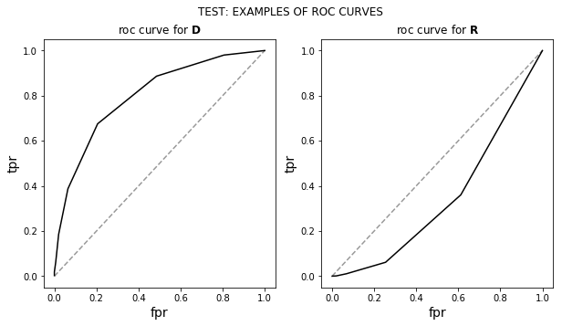

```python
# i is the index of the amino-acid in aa (D=3 and R=1)data
def single(i):
    Xvalid, yvalid = old_classification20[4], old_classification20[5]
    _, fpr, tpr = roc_curve(Xvalid[:,i], yvalid)
    # plot the results
    plt.plot(fpr, tpr, c='k'); plt.plot([0,1], [0,1], ls='--', c='k', alpha=0.4)
    plt.xlabel("fpr", fontsize=14); plt.ylabel("tpr", fontsize=14)

plt.figure(figsize=(10,5))
plt.subplot(121); single(3); plt.title(r'roc curve for $\bf{{{D}}}$')
plt.subplot(122); single(1); plt.title(r'roc curve for $\bf{{{R}}}$')
plt.suptitle('TEST: EXAMPLES OF ROC CURVES');
```

As previously observed, "R" (anti) "D", and "E" have the highest correlations with the score. Just to remind us, these sequences are the centroids of a clustering done using usearch, allowing up to 6 missmatches per sequence. We should not have duplicates or sequences derived from other sequences from the library in this data-sets. Classification has a smaller and more polarized dataset. Samples were labeled positives if $\sum_{bin=3}^{4} reads_{bin} > 2 * \sum_{bin=1}^{2} reads_{bin}$ or negatives if $\sum reads_{pre-selection} > 2 * \sum_{bin=2}^{4} reads_{bin}$.  
New data is more simple with no reads in bins1-4 = negatives and positive otherwise. Scores are a weighted sum of reads in each bin.

### Physico-chemical properties

**hydrophobicity**  
**charge**  
**volume**  
**mass**  
**WdV radius**

*iupred* and *psipred* predictions of disorder and 2$^{ry}$ structure are not included here. Most of these values include the main-chain. Hence, since WdV$_X$ = WdV$_{Gly}$ + WdV$_H$ (same for volume2) I will substract Gly from each other aminoacid.

```python
from physical_properties import properties
properties
```

|  | mass | volume1 | volume2 | hydrophobicity1 | hydrophobicity2 | pI | charge | VdW |
| --- | --- | --- | --- | --- | --- | --- | --- | --- |
| A | 71.0788 | -2.6 | 88.6 | 1.8 | 0.50 | 6.00 | 0.0 | 67 |
| R | 156.1875 | 7.9 | 173.4 | -4.5 | 1.81 | 10.76 | 1.0 | 148 |
| N | 114.1038 | 7.0 | 114.1 | -3.5 | 0.85 | 5.41 | 0.0 | 96 |
| D | 115.0886 | 11.9 | 111.1 | -3.5 | 3.64 | 2.77 | -1.0 | 91 |
| C | 103.1388 | -1.0 | 108.5 | 2.5 | -0.02 | 5.07 | 0.0 | 86 |
| E | 129.1155 | 8.5 | 138.4 | -3.5 | 3.63 | 3.22 | -1.0 | 109 |
| Q | 128.1307 | 1.3 | 143.8 | -3.5 | 0.77 | 5.65 | 0.0 | 114 |
| G | 57.0519 | 0.0 | 60.1 | -0.4 | 1.15 | 5.97 | 0.0 | 48 |
| H | 137.1411 | 3.3 | 153.2 | -3.2 | 0.11 | 7.59 | 0.5 | 118 |
| I | 113.1594 | -2.6 | 166.7 | 4.5 | -1.12 | 6.02 | 0.0 | 124 |
| L | 113.1594 | -6.2 | 166.7 | 3.8 | -1.25 | 5.98 | 0.0 | 124 |
| K | 128.1741 | 7.6 | 168.6 | -3.9 | 2.80 | 9.74 | 1.0 | 135 |
| M | 131.1926 | 0.7 | 162.9 | 1.9 | -0.67 | 5.74 | 0.0 | 124 |
| F | 147.1766 | -0.9 | 189.9 | 2.8 | -1.71 | 5.48 | 0.0 | 135 |
| P | 97.1167 | -6.2 | 112.7 | -1.6 | 0.14 | 6.30 | 0.0 | 90 |
| S | 87.0782 | 1.4 | 89.0 | -0.8 | 0.46 | 5.68 | 0.0 | 73 |
| T | 101.1051 | 0.3 | 116.1 | -0.7 | 0.25 | 5.60 | 0.0 | 93 |
| W | 186.2132 | 0.6 | 227.8 | -0.9 | -2.09 | 5.89 | 0.0 | 163 |
| Y | 163.1760 | -0.3 | 193.6 | -1.3 | -0.71 | 5.66 | 0.0 | 141 |
| V | 99.1326 | -3.6 | 140.0 | 4.2 | -0.46 | 5.96 | 0.0 | 105 |

```python
#############################
# Test all other properties #
#############################

properties = properties.drop('pI', axis=1) # It includes information about the main chain that is not relevant here.
properties['volume2'] = properties['volume2'] - 60.1
properties['VdW'] = properties['VdW'] - 48

# assign properties position-wise
def assign_property2seq(property_name, seq): return [properties.loc[res,property_name] for res in seq]

# Here I get a number for each sequence as a dot product between the vectors "property" and "aa_frequency"
def pre_model_regress(property_name, data): # feature_name is from properties and data are the sequences
    df = data[4].dot(properties.loc[aa, property_name])
    return spearmanr(df, data[5])

# same as above but with ROC_AUC as metric instead of spearman r
def pre_model_classif(property_name, data):
    df = data[4].dot(properties.loc[aa, property_name])
    _, fpr, tpr = roc_curve(df, data[5])
    return np.round(auc(fpr, tpr),3)

for prop in properties.columns:
    print('-'*50+'\n'+start+prop+end)
    k, v = [],[]
    for names, data in regression.items():
        corr = pre_model_regress(prop, data)
        k.append(names)
        v.append(np.round(corr[0],3))
    print(pd.DataFrame(v, index=k, columns=['r_values']).T)

    corr1 = pre_model_classif(prop, old_classification20)
    corr2 = pre_model_classif(prop, new_classification20)
    print(pd.DataFrame(np.array([corr1, corr2]), index=['old','new'], columns=['roc_auc']).T)
```

```
--------------------------------------------------
mass
            old  log(old)    new  log(new)
r_values  0.078     0.078  0.093     0.093
           old    new
roc_auc  0.558  0.567
--------------------------------------------------
volume1
            old  log(old)    new  log(new)
r_values  0.191     0.191  0.204     0.204
           old    new
roc_auc  0.634  0.602
--------------------------------------------------
volume2
            old  log(old)  new  log(new)
r_values  0.138     0.138  0.2       0.2
          old    new
roc_auc  0.62  0.618
--------------------------------------------------
hydrophobicity1
            old  log(old)    new  log(new)
r_values  0.217     0.217  0.363     0.363
           old    new
roc_auc  0.687  0.695
--------------------------------------------------
hydrophobicity2
            old  log(old)    new  log(new)
r_values  0.187     0.187  0.201     0.201
           old    new
roc_auc  0.627  0.587
--------------------------------------------------
charge
            old  log(old)    new  log(new)
r_values -0.606    -0.606 -0.768    -0.768
           old    new
roc_auc  0.068  0.063
--------------------------------------------------
VdW
            old  log(old)   new  log(new)
r_values  0.053     0.053  0.07      0.07
          old    new
roc_auc  0.55  0.542
```

Hydrophobicity may have little correlation and charge has a very strong correlation with the scores. I will work with amino-acid frequencies from now and will be back to these other features later if worth. Charge has the highest correlation with labels.  
First, I will test combinations of amino-acids with linear regression and ensemble trees models. Then I will test dense and convolutional networks of 1-6 layers which could exctract sequential information and will test amino-acid frequencies first and physico-chemical properties second (charge alone or in combination with hydrophobicity1 and volume).

### Linear combinations of amino-acid frequencies

```python
from sklearn.linear_model import RidgeCV
from sklearn.linear_model import LogisticRegressionCV

##########################
# Start with amino-acids #
##########################
print('-'*60+'\n'+start+'amino acid frequencies\n'+end+'-'*60)

### regression
all_r = []  # cols contains the names of the arrays
for data in all_data_regression:
    model = RidgeCV(alphas=10. ** np.arange(-2,2,.1))  # 40 tests
    model.fit(data[0], data[1])
    y_hat = model.predict(data[4])
    r, p = spearmanr(y_hat, data[5])
    all_r.append(np.round(r,3))

df = pd.DataFrame(all_r, index=cols, columns=['r_values']).T
print(df)

### classification
all_auc = []  # cols contains the names of the arrays
for data in all_data_classification:
    model = LogisticRegressionCV(Cs=np.linspace(1e-4,1e-2,40))
    model.fit(data[0], data[1])
    y_hat = model.predict(data[4])
    _, fpr, tpr = roc_curve(y_hat, data[5])
    all_auc.append(np.round(auc(fpr, tpr),3))

df = pd.DataFrame(all_auc, index=['old','new'], columns=['roc_auc']).T
print(df)
```

```
------------------------------------------------------------
amino acid frequencies
------------------------------------------------------------
            old  log(old)    new  log(new)
r_values  0.647     0.663  0.794      0.81
           old    new
roc_auc  0.799  0.828
```

If I shuffle the labels I should loose these good r_values and roc_auc should be ~0.5

```python
print('-'*60+'\n'+start+'amino acid frequencies with shuffled labels\n'+end+'-'*60)

### regression
all_r = []  # cols contains the names of the arrays
for data in all_data_regression:
    model = RidgeCV(alphas=10. ** np.arange(-2,2,.1))  # 40 tests
    d1 = [i for i in data[1]]
    np.random.shuffle(d1)
    model.fit(data[0], d1) #data[1])
    y_hat = model.predict(data[4])
    r, p = spearmanr(y_hat, data[5])
    all_r.append(np.round(r,3))

df = pd.DataFrame(all_r, index=cols, columns=['r_values']).T
print(df)

### classification
all_auc = []  # cols contains the names of the arrays
for data in all_data_classification:
    model = LogisticRegressionCV(Cs=np.linspace(1e-4,1e-2,40))
    d1 = [i for i in data[1]]
    np.random.shuffle(d1)
    model.fit(data[0], d1) #data[1])    y_hat = model.predict(data[4])
    _, fpr, tpr = roc_curve(y_hat, data[5])
    all_auc.append(np.round(auc(fpr, tpr),3))

df = pd.DataFrame(all_auc, index=['old','new'], columns=['roc_auc']).T
print(df)
```

```
------------------------------------------------------------
amino acid frequencies with shuffled labels
------------------------------------------------------------
            old  log(old)    new  log(new)
r_values  0.008    -0.174 -0.129    -0.366
           old    new
roc_auc  0.496  0.304
```

The model is not performing well by chance! The combination of amino-acid frequencies is highly correlated with TAD activity of a sequence. These values are about the same if I use test instead of validation, this is good...

### Using 2-mers ( frequencies)

Can a linear combination of 2-mers frequencies predict the scores or labels better than single amino-acid frequencies? Using Lasso (L1 regularization), the weight of many 2-mers can be set to 0 and it might be easier to find the 2-mers with highest weights in the linear regression model of 2-mer frequencies. I will start by regularizing with L2 (Ridge) and next do the L1.

```python
# Taken literally from Jacob's notebook. I can't be more clear nor shorter!
import itertools

# list all "k"-mers that exist in the sequence "seq"
def kmerize(seq, k):
    return ' '.join(seq[i:i+k] for i in range(len(seq) -k +1))

# generate all possible k-mers from "aa" list
def kmers(k):
    return [''.join(kmers) for kmers in itertools.product(aa, repeat=k)]

# generate one column for each of all possible kmers in data (k=2 here)
for kmer in kmers(2):
    old_data_regress[kmer] = [kmerize(seq, 2).count(kmer) / 29. for seq  in old_data_regress.index]
    old_data_classif[kmer] = [kmerize(seq, 2).count(kmer) / 29. for seq  in old_data_classif.index]
    new_data[kmer] = [kmerize(seq, 2).count(kmer) / 29. for seq in new_data.index]
```

```python
### redefine the data with the 2-mers ###
old_regression400 = split_data(idx = idx_old_data_regress,
                            data = old_data_regress,
                            selection=kmers(2),
                            column_label_score_NAME='scores')

old_log_regression400 = split_data(idx_old_data_regress, old_data_regress, kmers(2), 'log_scores')
old_classification400 = split_data(idx_old_data_classif, old_data_classif, kmers(2), 'TAD')

new_regression400 = split_data(idx_new_data, new_data, kmers(2), 'scores')
new_log_regression400 = split_data(idx_new_data, new_data, kmers(2), 'log_scores')
new_classification400 = split_data(idx_new_data, new_data, kmers(2), 'TAD')


# regression
names = ['old','old_log', 'new','new_log']
regression = [old_regression400, old_log_regression400, new_regression400, new_log_regression400]
regression = dict(zip(names, regression))

r_values, keys, models = [], [], []
for key, values in regression.items():
    model = RidgeCV(alphas=10. **(np.arange(-2,2,.1)))
    model.fit(values[0], values[1])
    models.append(model)
    y_hat = model.predict(values[4])
    r_values.append(spearmanr(y_hat, values[5])[0])
    keys.append(key)
r_values = pd.DataFrame(r_values, index=keys, columns=['r_values']).T
print(start+'regression'+end)
print(r_values)

# classification
r_values, accuracies, model_cs = [],[],[]
for values in [old_classification400, new_classification400]:
    model_c = LogisticRegressionCV(Cs=np.linspace(1e-4,1e-1,40))
    model_c.fit(values[0], values[1])
    model_cs.append(model_c)
    y_hat = model_c.predict(values[4])
    _, fpr, tpr = roc_curve(y_hat, values[5])
    accuracies.append(np.round(model_c.score(values[4], values[5]),3))
    r_values.append(np.round(auc(fpr, tpr),3))

print(start+'classification'+end)
print('acc: old={},  new={}'.format(accuracies[0], accuracies[1]))
print('roc_auc: old={},  new={}'.format(r_values[0], r_values[1]))
```

```
regression
               old   old_log     new  new_log
r_values  0.638862  0.670414  0.7905  0.81644
classification
acc: old=0.849,  new=0.873
roc_auc: old=0.798,  new=0.835
```

There is not a big improvement using 2-mers over single amino-acid frequencies.

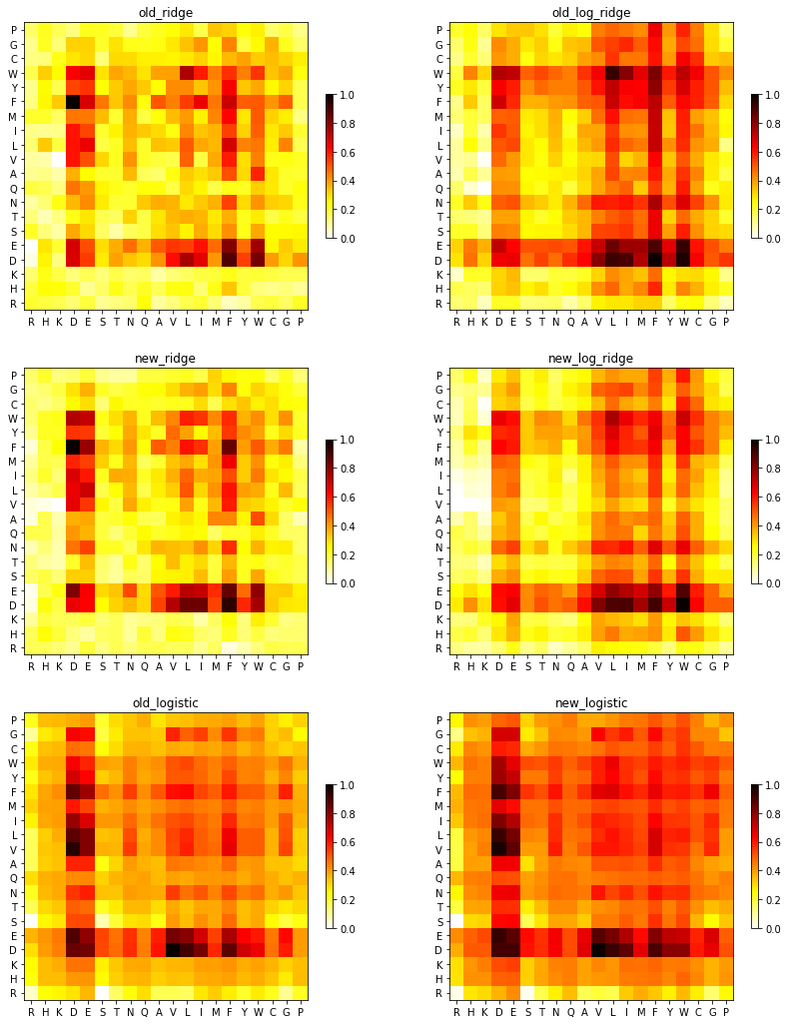

```python
# fx to get the 2d coordinate of combination in the Ridge's weights matrix
position = lambda km: [aa.index(j) for j in km]
scale = lambda X: (X-np.min(X))/(np.max(X)-np.min(X))

plt.figure(figsize=(14,18))
titles = ['old_ridge','old_log_ridge', 'new_ridge', 'new_log_ridge','old_logistic', 'new_logistic']
coefs = [scale(i.coef_) for i in models] + [scale(i.coef_[0]) for i in model_cs]

for p, [data,title] in enumerate(zip(coefs, titles)):
    # Will fill this matrix with LASSO weights from all combinations
    matrix = np.zeros(shape=(20,20))

    for n,i in enumerate(kmers(2)):
        a,b = position(i)
        matrix[a][b] = data[n]

    ax = plt.subplot(3,2,p+1)
    im = ax.pcolor(matrix, cmap='hot_r')
    plt.colorbar(im, shrink=0.5)
    ax.set_xticks(np.arange(20)+.5)
    ax.set_yticks(np.arange(20)+.5)
    ax.set_xticklabels(aa); ax.set_yticklabels(aa)
    plt.title(title);
```

Using L1 regularization instead of L2, I can reduce the number of 2-mers with coefficient>0 and might observer a heatmap with higher contrast.

I can also inspect the model, plotting MSE using different $\lambda$s

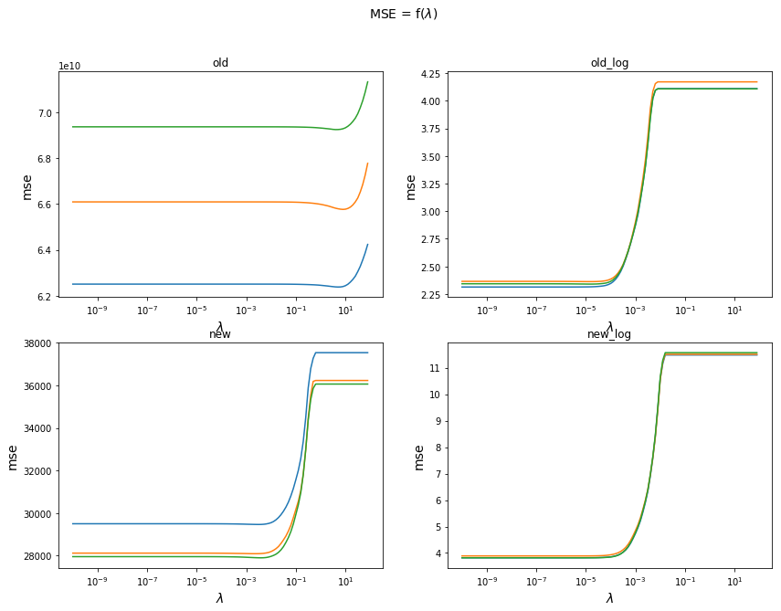

```python
from sklearn.linear_model import LassoCV

plt.figure(figsize=(14,10))

r_values, keys, models = [],[],[]
for n, [key, values] in enumerate(regression.items()):

    model = LassoCV(alphas=10. ** np.arange(-10,2,.1))
    model.fit(values[0], values[1])
    y_hat = model.predict(values[4])
    r_values.append(spearmanr(y_hat, values[5]))
    keys.append(key)
    models.append(model)

    plt.subplot(2,2,n+1)
    plt.plot(model.alphas_, model.mse_path_)
    plt.xscale("log")
    plt.xlabel("$\lambda$", fontsize=14)
    plt.ylabel('mse', fontsize=14)
    plt.title(key)
    plt.suptitle("MSE = f($\lambda$)", fontsize=14)
```

Three lines from a 3-fold CV.  
Low $\lambda$ => no regularization., high $\lambda$ => underfiting due to too strong regularization. There is no need for regularization in this model, anyway.

How many coefficients are 0?

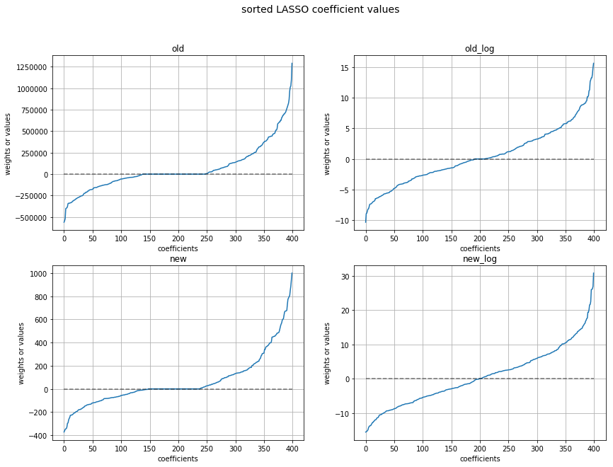

```python
# plot sorted coefficients from LASSO
plt.figure(figsize=(14,10))

for n, [title, data] in enumerate(zip(keys, models)):
    coefs = np.sort(data.coef_)
    plt.subplot(2,2,n+1)
    plt.plot(coefs)
    plt.ylabel('weights or values')
    plt.xlabel('coefficients')
    plt.plot((0,400),(0,0), ls='--', c='k', alpha=0.5)
    plt.grid()
    plt.title(title)

plt.suptitle("sorted LASSO coefficient values", fontsize=14);
```

What are the 2-mers most correlated with the scores?

```
di-peptides highly correlated with TAD activity in the old data

['DL' 'DF' 'DW' 'ED' 'EF' 'EW' 'LF' 'FD' 'FF' 'WL']


di-peptides highly anti-correlated with TAD activity in the old data

['RF' 'HE' 'HP' 'KA' 'DR' 'DK' 'ER' 'SH' 'SK' 'ST' 'TR' 'TH' 'TK' 'NR'
 'QK' 'AR' 'AH' 'AK' 'VR' 'VH' 'VK' 'LR' 'IR' 'IH' 'IK' 'FR' 'YR' 'CR'
 'GR' 'GK' 'PR' 'PN' 'PP']
```

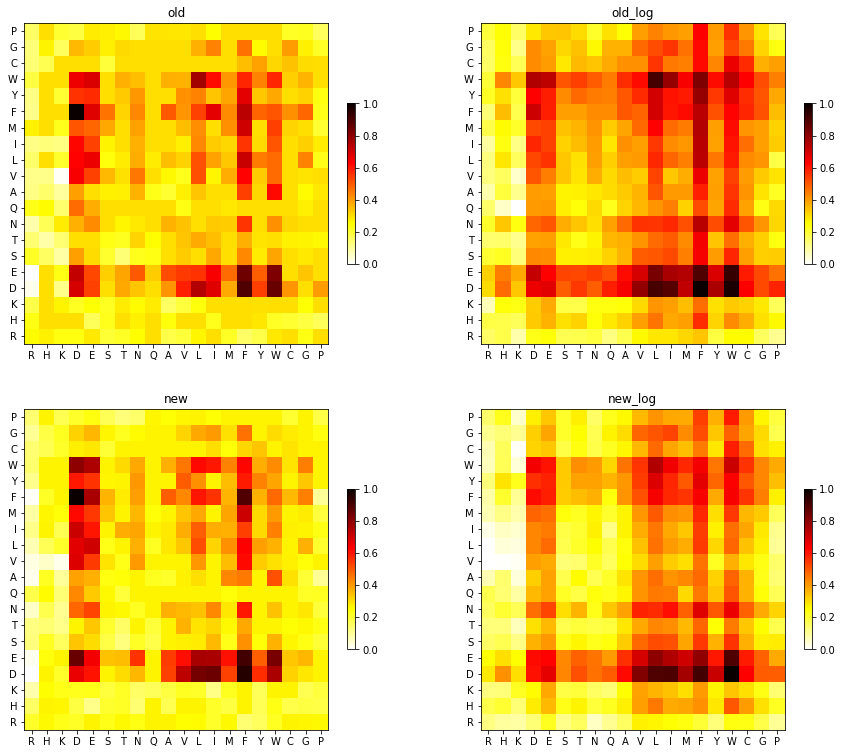

```python
# I call the weights heavy and light. Will search for heavy and light di-peptides from the LASSO model in the old data.
heavy = np.hstack(np.where(models[0].coef_>750000))
light = np.hstack(np.where(models[0].coef_<-250000))

print('di-peptides highly '+start+'correlated'+end+' with TAD activity in the old data\n')
print(np.array([kmers(2)[i] for i in heavy])); print('\n')
print('di-peptides highly '+start+'anti-correlated'+end+' with TAD activity in the old data\n')
print(np.array([kmers(2)[i] for i in light]))


plt.figure(figsize=(15,13))
for p, [title, data] in enumerate(zip(keys, models)):
    # Will fill this matrix with LASSO weights from all combinations
    matrix = np.zeros(shape=(20,20))
    matrix_log = np.zeros(shape=(20,20))

    for n,i in enumerate(kmers(2)):
        a,b = position(i)
        matrix[a][b] = data.coef_[n]

    ax = plt.subplot(2,2,p+1)
    ax.set_title(title)
    im = ax.pcolor(scale(matrix), cmap='hot_r')
    plt.colorbar(im, shrink=0.5)
    ax.set_xticks(np.arange(20)+.5);
    ax.set_yticks(np.arange(20)+.5);
    ax.set_xticklabels(aa); ax.set_yticklabels(aa);
```

Negatively charged residues were described by Ptashne, Struhl and others to be an important characteristic of TADs. Steve's PNAS from 2014 shows that W,L and F were involved in the strongest TAD motifs of Gcn4. Here we have both concepts summarized in di-peptides!  
Is the difference between 'FD' and 'DF' significant?

If there is extra-information in di-peptides but the data is more noisy, then we don't get higher performance of the 2-mers model with respect to the linear combination of single amino-acid frequencies.  
In that case, combining the 20 aa to the 400 2-mers to a total of 420 features could provide a better model. I will do this using L1 and L2.

```python
# 420-data is composed of single aa AND 2mers

old_regression420 = split_data(idx = idx_old_data_regress,
                            data = old_data_regress,
                            selection=aa+kmers(2),
                            column_label_score_NAME='scores')

old_log_regression420 = split_data(idx_old_data_regress, old_data_regress, aa+kmers(2), 'log_scores')
old_classification420 = split_data(idx_old_data_classif, old_data_classif, aa+kmers(2), 'TAD')

new_regression420 = split_data(idx_new_data, new_data, aa+kmers(2), 'scores')
new_log_regression420 = split_data(idx_new_data, new_data, aa+kmers(2), 'log_scores')
new_classification420 = split_data(idx_new_data, new_data, aa+kmers(2), 'TAD')


# regression
names = ['old','old_log', 'new','new_log']
regression = [old_regression420, old_log_regression420, new_regression420, new_log_regression420]
regression = dict(zip(names, regression))

keys, r_values, models = [],[],[]
for key, values in regression.items():
    model = RidgeCV(alphas=10. **(np.arange(-2,2,.1)))
    model.fit(values[0], values[1])
    models.append(model)
    y_hat = model.predict(values[4])
    r_values.append(spearmanr(y_hat, values[5])[0])
    keys.append(key)
r_values = pd.DataFrame(r_values, index=keys, columns=['r_values']).T
print(start+'regression'+end)
print(r_values)

# classification
r_values, accuracies, model_cs = [],[],[]
for values in [old_classification420, new_classification420]:
    model_c = LogisticRegressionCV(Cs=np.linspace(1e-4,1e-1,40))
    model_c.fit(values[0], values[1])
    model_cs.append(model_c)
    y_hat = model_c.predict(values[4])
    _, fpr, tpr = roc_curve(y_hat, values[5])
    accuracies.append(np.round(model_c.score(values[4], values[5]),3))
    r_values.append(np.round(auc(fpr, tpr),3))

print(start+'classification'+end)
print('acc: old={},  new={}'.format(accuracies[0], accuracies[1]))
print('roc_auc: old={},  new={}'.format(r_values[0], r_values[1]))


print(start+'Lasso regression'+end)
r_values, keys, models = [],[],[]

for n, [key, values] in enumerate(regression.items()):
    model = LassoCV(alphas=10. ** np.arange(-10,2,.1))
    model.fit(values[0], values[1])
    y_hat = model.predict(values[4])
    r_values.append(spearmanr(y_hat, values[5])[0])
    keys.append(key)
    models.append(model)
r_values = pd.DataFrame(r_values, index=keys, columns=['r_values']).T
print(r_values)
```

```
regression
               old   old_log       new   new_log
r_values  0.649352  0.671571  0.795308  0.816813
classification
acc: old=0.875,  new=0.901
roc_auc: old=0.819,  new=0.858
Lasso regression
               old   old_log       new  new_log
r_values  0.649398  0.670568  0.795058   0.8168
```

There is a mild improvement in the performance of the linear regression model when combining *2-mers* AND *single amino-acid frequencies*, specially in the classification framework.  
Frequency of negatively charged residues appears to be a very important factor for 30mers to behave as TADs. 2-mer frequencies provide a very mild higher performance to the linear regression model. Nevertheless, I can clearly see that amino-acids with highest correlation with the activity of TADs have very different coefficients in a 2-mer linear regression, depending on their combinations with other amino-acids. Could the combined model perform better?

If linear models can't fit some additional information contained in 2-mers compared to single aa frequencies, ensemble of decision trees might be able to do it. I will use gradient boosting and neural networks next. I might try SVM later?

First, XGBoost with default hyper-parameters and then I try to optimize these parameters

## XG boosting models

```python
# Since the new data shows better performance in all models, I will keep using only this one.
from sklearn.metrics import make_scorer
def spearman_score(x,y): return spearmanr(x,y)[0]
def auc_score(x,y):
    _, fpr, tpr = roc_curve(x,y)
    return auc(fpr, tpr)

# xgboost with default parameters
import xgboost

# REGRESSION
model = xgboost.XGBRegressor(scoring=make_scorer(spearman_score), random_state=0)
model.fit(new_regression420[0], new_regression420[1])
y_hat = model.predict(new_regression420[4])

print(start+'REGRESSION'+end+': performance using single aa + 2-mers in XGBoost default parameters')
print(spearmanr(y_hat, new_regression420[5]))

# CLASSIFICATION
model = xgboost.XGBClassifier(scoring=make_scorer(auc_score), random_state=0)
model.fit(new_classification420[0], new_classification420[1])
y_hat = model.predict(new_classification420[4])
_, fpr, tpr = roc_curve(y_hat, new_classification420[5])

print(start+'CLASSIFICATION'+end+': performance  using single aa + 2-mers in XGBoost default parameters')
print(auc(fpr, tpr))
```

```
REGRESSION: performance using single aa + 2-mers in XGBoost default parameters
SpearmanrResult(correlation=0.7937355719602842, pvalue=0.0)
CLASSIFICATION: performance  using single aa + 2-mers in XGBoost default parameters
0.8585024579593272
```

```python
# xgboost models where run with sbatch --> new_log library used here

'''# import libraries
from sklearn.model_selection import RandomizedSearchCV
from sklearn.metrics import make_scorer
import xgboost

# score funtion to use for optimization
def spearman_score(x, y): return spearmanr(x, y)[0]
def auc_score(x,y):
    _, fpr, tpr = roc_curve(x,y)
    return auc(fpr, tpr)

# parameters to optimize
params = {
    'n_estimators' : [50, 100, 400],
    'max_depth' : [1, 3, 5],
    'learning_rate' : [1.0, 0.2, 0.01],
    'gamma' : [0, 0.5, 1],
    'reg_lambda' : 10. ** numpy.arange(-1, 1, 0.5),
    'subsample' : [0.5, 1],
}

# REGRESSION
model = RandomizedSearchCV(xgboost.XGBRegressor(),
                           param_distributions=params,
                           n_iter=648,
                           scoring=make_scorer(spearman_score),
                           cv=3,
                           n_jobs=-1,
                           verbose=1,
                           random_state=0)

model.fit(aa_regression420[0], aa_regression420[1])
y_hat = model.predict(aa_regression420[4])

print(start+'REGRESSION: performance using single aa + 2-mers in XGBoost optimized')
print(spearmanr(y_hat, aa_regression420[5]))

# CLASSIFICATION
model = RandomizedSearchCV(xgboost.XGBClassifier(),
                           param_distributions=params,
                           n_iter=648,
                           scoring=make_scorer(auc_score),
                           cv=3,
                           n_jobs=-1,
                           verbose=1,
                           random_state=0)

model.fit(aa_classification420[0], aa_classification420[1])
y_hat = model.predict(aa_classification420[4])
_, fpr, tpr = roc_curve(y_hat, aa_classification420[5])

print(start+'CLASSIFICATION: performance  using single aa + 2-mers in XGBoost optimized')
print(auc(fpr, tpr))''';
```

So... The benchmark for classification using linear models was **roc_auc = 0.85**. There is no improvement in performance using gradient boosting with default parameters. Next I optimize the parameters of a XGBoost model.

I assume that, given there is a motif, it might be "anywhere" in the sequence and there might be "tandem" or "distant" interactions that are major contributors to the TAD and location of single amino-acids will not correlate with scores or labels.

### Is there any preference of particular amino-acids to be located towards the "N" terminal or "nearby" the DNA binding domain?

```python
def one_hot_encode(seq):
    X = np.zeros(shape=(len(seq),len(aa)))
    try:
        for n,i in enumerate(seq): X[n, aa.index(i)] = 1
        return X
    except exception as e:
        print('exception {} encountered'.format(e))

print(aa)
print(new_data.index[0])
print(one_hot_encode(new_data.index[0])[:5])#.flatten())
```

```
['R', 'H', 'K', 'D', 'E', 'S', 'T', 'N', 'Q', 'A', 'V', 'L', 'I', 'M', 'F', 'Y', 'W', 'C', 'G', 'P']
REEDFYVNELRNTENESIFYVEFENILDGL
[[1. 0. 0. 0. 0. 0. 0. 0. 0. 0. 0. 0. 0. 0. 0. 0. 0. 0. 0. 0.]
 [0. 0. 0. 0. 1. 0. 0. 0. 0. 0. 0. 0. 0. 0. 0. 0. 0. 0. 0. 0.]
 [0. 0. 0. 0. 1. 0. 0. 0. 0. 0. 0. 0. 0. 0. 0. 0. 0. 0. 0. 0.]
 [0. 0. 0. 1. 0. 0. 0. 0. 0. 0. 0. 0. 0. 0. 0. 0. 0. 0. 0. 0.]
 [0. 0. 0. 0. 0. 0. 0. 0. 0. 0. 0. 0. 0. 0. 1. 0. 0. 0. 0. 0.]]
```

I will start with single amino-acids and might try to repeat the procedure for di-peptides.peptides

```python
# regression
datasets = {'old': [old_data_regress, idx_old_data_regress],
            'new': [new_data, idx_new_data]}
r_values = {}

for key, [data,idx] in datasets.items():
    singles = data.index
    singles = np.array([one_hot_encode(i) for i in singles]).reshape(singles.shape[0],600)
    ohe_data = pd.DataFrame(singles, index=data.index)
    for score in ['scores','log_scores']:
        ohe_regress20 = pd.concat([ohe_data, data[score]],axis=1)
        # split the data as before
        ohe_regress20 = split_data(idx, ohe_regress20, np.arange(0,600), score)
        # append values to r_values
        corrs = np.zeros(600)
        [x_train, y_train, x_valid, y_valid] = [ohe_regress20[i] for i in [0,1,4,5]]
        # get spearman correlations
        for n,r in enumerate(x_valid.T):
            corrs[n] = spearmanr(r, y_valid)[0]
            r_key = '_'.join([key,score])
        r_values[r_key] = corrs

# classification
datasets = {'old': [old_data_classif, idx_old_data_classif],
            'new': [new_data, idx_new_data]}
auc_values = {}

for key, [data, idx] in datasets.items():
    singles = data.index
    singles = np.array([one_hot_encode(i) for i in singles]).reshape(singles.shape[0],600)
    ohe_data = pd.DataFrame(singles, index=data.index)

    # keep this data for same splitting as before
    ohe_data = pd.concat([ohe_data, data.TAD],axis=1)
    ohe_classif20 = split_data(idx, ohe_data, np.arange(0,600), 'TAD')

    # append values to auc_values
    corrs = np.zeros(600)
    [x_train, y_train, x_valid, y_valid] = [ohe_classif20[i] for i in [0,1,4,5]]
    # get spearman correlations
    for n,r in enumerate(x_valid.T):
        _, fpr, tpr = roc_curve(r, y_valid)
        corrs[n] = auc(fpr, tpr)
    auc_values[key] = corrs
```

I have 20 amino-acids x 30 positions and will corelate each of these 600 columns with the score. I will plot a histogram of spearman r values to observe their distribution and boundaries but I will also plot a 2D heatmap to potentially recognize aa that show better correlation with score at a particular position in the sequence.

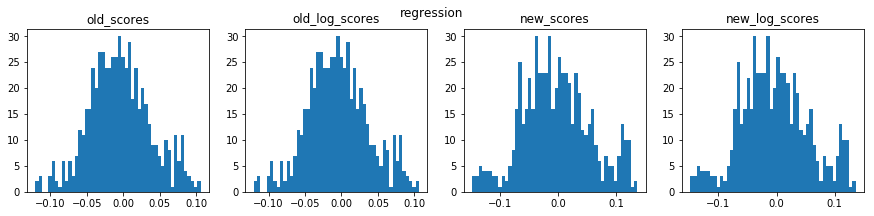

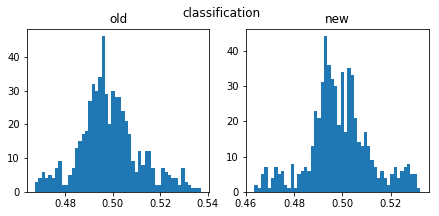

```python
# plot histograms
# regression
plt.figure(figsize=(15,3))
plt.suptitle('regression')
for n, [k,v] in enumerate(r_values.items()):
    plt.subplot(1,4,n+1)
    plt.title(k)
    plt.hist(v, bins=50);
# classification
plt.figure(figsize=(7.2,3))
plt.suptitle('classification')
for n, [k,v] in enumerate(auc_values.items()):
    plt.subplot(1,2,n+1)
    plt.title(k)
    plt.hist(v, bins=50);
```

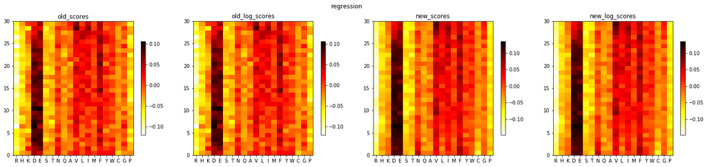

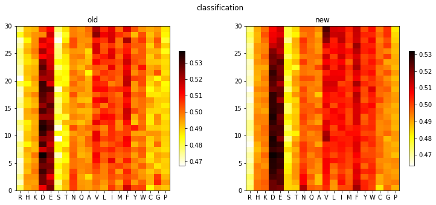

```python
# plot heatmaps
f, ax = plt.subplots(1,4, figsize=(25,5))
plt.suptitle('regression')
for n, [k,v] in enumerate(r_values.items()):
    ax[n].set_title(k)
    im = ax[n].pcolor(v.reshape(30,20), cmap="hot_r")
    ax[n].set_xticks(np.arange(0.5, 20.5))
    ax[n].set_xticklabels(aa)
    plt.colorbar(im, shrink=0.7, ax=ax[n])

# classification
f, ax = plt.subplots(1,2, figsize=(12.5,5))
plt.suptitle('classification')
for n, [k,v] in enumerate(auc_values.items()):
    ax[n].set_title(k)
    im = ax[n].pcolor(v.reshape(30,20), cmap="hot_r")
    ax[n].set_xticks(np.arange(0.5, 20.5))
    ax[n].set_xticklabels(aa)
    plt.colorbar(im, shrink=0.7, ax=ax[n])
```

**All values are below 0.15 or above -0.15 so conclusions from this plot might be irrelevant**  
My observation is that the correlation of "D" and "E" (also anticorrelation of "R") seem to decrease towards the DNA Binding Domain or DBD (it goes N$_t$--TAD-DBD--C$_t$).

On the other hand, V,L and F seem to correlate better when they are present close to the DBD.

AUC=0.5 would be equivalent to a spearman=0

```python
## YOU CAN BYPASS THIS CELL!! too many combinations. I can zoom it (scipy-ndimage) and then plot the heatmap, but 1- too many zeroes
#2- zooming might not be informative...

# 2-mers:  400 x 30=1200 columns x 62395 rows of di-peptides data...
'''_2mers = kmers(2)
# generate one column for each of all possible 2-mers for all 30 positions in data
def one_hot_encode_2mers(seq):
    X = np.zeros(shape=(len(seq),len(_2mers)))
    try:
        for n in range(len(seq)-1):
            _1, _2 = seq[n], seq[n+1]
            X[aa.index(_1), aa.index(_2)] = 1
        return X
    except exception as e:
        print('exception {} encountered'.format(e))

print(new_data.index[0])
print(one_hot_encode_2mers(new_data.index[0]).shape)#.flatten().shape)


doubles = new_data.index
doubles = np.array([one_hot_encode_2mers(i) for i in doubles]).reshape(doubles.shape[0],12000)

#cols = np.concatenate([[''.join([str(i),'_',j]) for j in kmers(2)] for i in range(30)])
cols = [i for i in itertools.product(np.arange(1,31),_2mers)]
ohe_data = pd.DataFrame(doubles, index=new_data.index, columns=cols)

ohe_data_regress = pd.concat([ohe_data, new_data.log_scores],axis=1)
ohe_data_classif = pd.concat([ohe_data, new_data.TAD],axis=1)

# repeat the split as I did it previously
regression = split_data(idx_new_data, ohe_data_regress, np.arange(0,12000), 'log_scores')
classification = split_data(idx_new_data, ohe_data_classif, np.arange(0,12000), 'TAD')
ohe_data_regress.head(4)''';
```

### Deep learning predictions

I will start with a Dense network which is fast to train and then I will train on the gizmo server a convolutional network and a convolutional + recurrent network later.

Since the classification task is performing better (scores might be less precise than labels) and to keep this notebook more clear to follow, I am only doing neural networks on classification with the new data.

I will optimize the number of layers and the number of nodes per layer in a dense network first.

```python
from keras.models import Sequential
from keras.layers import Dense, Conv1D, Conv2D, Flatten, LSTM, Dropout
from keras.callbacks import EarlyStopping
from tqdm import tqdm
import keras.backend as K
```

```python
# Generate the data with one hot encoding for single positions and even though I am going to test
# convolutional networks, I will also test the 2-mers.

# produce the ohe for the new_data
singles = new_data.index
singles = np.array([one_hot_encode(i) for i in singles]).reshape(singles.shape[0],600)
print(singles.shape)

# join ohe with scores or labels
ohe_data = pd.DataFrame(singles, index=new_data.index)
ohe_data_regress = pd.concat([ohe_data, new_data.log_scores],axis=1)
ohe_data_classif = pd.concat([ohe_data, new_data.TAD],axis=1)

# split data
regression = split_data(idx_new_data, ohe_data_regress, np.arange(0,600), 'log_scores')
classification = split_data(idx_new_data, ohe_data_classif, np.arange(0,600), 'TAD')
ohe_data_regress.head(4)
```

```
(75846, 600)
```

|  | 0 | 1 | 2 | 3 | 4 | 5 | 6 | 7 | 8 | 9 | ... | 591 | 592 | 593 | 594 | 595 | 596 | 597 | 598 | 599 | log_scores |
| --- | --- | --- | --- | --- | --- | --- | --- | --- | --- | --- | --- | --- | --- | --- | --- | --- | --- | --- | --- | --- | --- |
| REEDFYVNELRNTENESIFYVEFENILDGL | 1.0 | 0.0 | 0.0 | 0.0 | 0.0 | 0.0 | 0.0 | 0.0 | 0.0 | 0.0 | ... | 1.0 | 0.0 | 0.0 | 0.0 | 0.0 | 0.0 | 0.0 | 0.0 | 0.0 | 8.415075 |
| GFLEPSLDITLVDAYDFLSCNCPMDVVGYW | 0.0 | 0.0 | 0.0 | 0.0 | 0.0 | 0.0 | 0.0 | 0.0 | 0.0 | 0.0 | ... | 0.0 | 0.0 | 0.0 | 0.0 | 0.0 | 1.0 | 0.0 | 0.0 | 0.0 | 8.100029 |
| WDLTVSVEDYINEVDFEDLFLEEIEFDTLV | 0.0 | 0.0 | 0.0 | 0.0 | 0.0 | 0.0 | 0.0 | 0.0 | 0.0 | 0.0 | ... | 0.0 | 0.0 | 0.0 | 0.0 | 0.0 | 0.0 | 0.0 | 0.0 | 0.0 | 7.964808 |
| VLGVGAGEDDWLDELWALGVMDNFSGYIDQ | 0.0 | 0.0 | 0.0 | 0.0 | 0.0 | 0.0 | 0.0 | 0.0 | 0.0 | 0.0 | ... | 0.0 | 0.0 | 0.0 | 0.0 | 0.0 | 0.0 | 0.0 | 0.0 | 0.0 | 7.899340 |

4 rows × 601 columns

#### Dense

```python
# go over the # of layers and nodes and see which is
# the # of parameters that gives the best correlation with real labels.

callback = EarlyStopping(patience=1)
num_layers, num_nodes = range(1,6), [5,30,60]

corrs = []

for nlayers, nnodes in tqdm(itertools.product(num_layers, num_nodes)):
    np.random.seed=0

    K.clear_session()
    model = Sequential()
    model.add(Dense(nnodes, activation='relu', input_shape=(600,)))

    for i in range(nlayers-1):
        model.add(Dense(nnodes, activation='relu'))

    model.add(Dense(1))
    model.compile(optimizer='adam', loss='binary_crossentropy', metrics=['accuracy'])
    model.fit(classification[0], classification[1],
              epochs=100,
              validation_split=0.1,
              callbacks=[callback],
              verbose=0)

    y_pred = model.predict(classification[4])
    _, fpr, tpr = roc_curve(y_pred, classification[5])
    corrs.append([nlayers, nnodes, model.count_params(), auc(fpr, tpr)])
    #corrs.append([nlayers, nnodes, model.count_params(), spearmanr(y_pred, regression[5])])

corrs = np.array(corrs);
```

```
15it [03:05, 12.35s/it]
```

|  | layers | nodes | parameters | auc |
| --- | --- | --- | --- | --- |
| 12 | 5.0 | 5.0 | 3131.0 | 0.963311 |
| 10 | 4.0 | 30.0 | 20851.0 | 0.963115 |
| 5 | 2.0 | 60.0 | 39781.0 | 0.961787 |
| 11 | 4.0 | 60.0 | 47101.0 | 0.961621 |
| 9 | 4.0 | 5.0 | 3101.0 | 0.961435 |
| 14 | 5.0 | 60.0 | 50761.0 | 0.961294 |
| 8 | 3.0 | 60.0 | 43441.0 | 0.960032 |
| 4 | 2.0 | 30.0 | 18991.0 | 0.959802 |
| 3 | 2.0 | 5.0 | 3041.0 | 0.959625 |
| 2 | 1.0 | 60.0 | 36121.0 | 0.959292 |
| 7 | 3.0 | 30.0 | 19921.0 | 0.958748 |
| 1 | 1.0 | 30.0 | 18061.0 | 0.958733 |
| 0 | 1.0 | 5.0 | 3011.0 | 0.958076 |
| 6 | 3.0 | 5.0 | 3071.0 | 0.957979 |
| 13 | 5.0 | 30.0 | 21781.0 | 0.954425 |

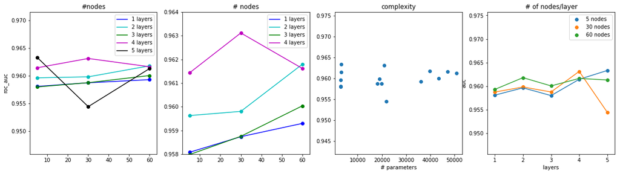

```python
plt.figure(figsize=(20,5))
colors = ['r','b','c','g','m','k']
def P(x,y, i):
    plt.scatter(x, y, c=colors[i])
    plt.plot(x, y, label=str(i)+' layers', c=colors[i])
    plt.legend()


plt.subplot(141)
plt.title('#nodes')
for i in range(1,6):
    tmp = corrs[corrs[:,0]==i]
    P(tmp[:,1], tmp[:,3], i)
plt.ylabel('roc_auc')

plt.subplot(142)
plt.title('# nodes')
for i in [1,2,3,4]:
    tmp = corrs[corrs[:,0]==i]
    P(tmp[:,1], tmp[:,3], i)
plt.ylim(0.958, 0.964)

plt.subplot(143)
plt.title('complexity')
plt.scatter(corrs[:,2], corrs[:,3])
plt.xlabel('# parameters')

plt.subplot(144)
plt.title('# of nodes/layer')
for i in [5,30,60]:
    tmp = corrs[corrs[:,1]==i]
    plt.scatter(tmp[:,0], tmp[:,3], label=str(i)+' nodes')
    plt.plot(tmp[:,0], tmp[:,3])
plt.legend()
plt.xlabel('layers')
plt.ylabel('auc');


pd.DataFrame(corrs, columns=['layers','nodes','parameters','auc']).sort_values('auc', ascending=False)
```

1- With only 5 nodes, Neural Networks are learning something that is not being captured by linear methods nor by xgboost. The difference is large and at this point I don't know how to explain the improvement in performance of NN over xgboost.

#### Convolutional networks

I assume that, if there are motifs that correlate with TAD activity, the convolutional models could learn them.

```python
# reshape the matrices for the convolutions
Xtrain, Xvalid = [classification[i].reshape(classification[i].shape[0], 30,20,1) for i in [0,4]]

num_conv_layers, num_conv_filters = range(1,4), [5,30]# 2**np.arange(7)
filter_width, num_nodes = [2,3,6], [30]#[5,30,60]

callback = EarlyStopping(patience=1)
params = [num_conv_layers, num_conv_filters, filter_width, num_nodes]
corrs = []
for ncl, ncf, fw, nnodes in tqdm(itertools.product(*params)):
    K.clear_session()
    model = Sequential()
    model.add(Conv2D(ncf, (fw,20), activation='relu', padding='same', input_shape=(30,20,1)))

    for l in range(ncl-1):
        model.add(Conv2D(ncf, (fw,20), activation='relu', padding='same'))

    model.add(Flatten())
    model.add(Dense(nnodes, activation='relu'))
    model.add(Dense(1))

    model.compile(optimizer='adam', loss='binary_crossentropy', metrics=['accuracy'])

    model.fit(Xtrain, classification[1], epochs=100, validation_split=0.1, callbacks=[callback], verbose=0)


    y_pred = model.predict(Xvalid)
    _, fpr, tpr = roc_curve(y_pred, classification[5])
    corr = auc(fpr, tpr)
    corrs.append([ncl, ncf, fw, nnodes, model.count_params(), corr])

corrs = np.array(corrs)
```

```
18it [1:36:47, 322.64s/it]
```

|  | conv layers | conv_filters | filter_width | nodes | parameters | auc |
| --- | --- | --- | --- | --- | --- | --- |
| 13 | 3.0 | 5.0 | 3.0 | 30.0 | 93376.0 | 0.962915 |
| 1 | 1.0 | 5.0 | 3.0 | 30.0 | 90366.0 | 0.959011 |
| 0 | 1.0 | 5.0 | 2.0 | 30.0 | 90266.0 | 0.958885 |
| 6 | 2.0 | 5.0 | 2.0 | 30.0 | 91271.0 | 0.951998 |
| 2 | 1.0 | 5.0 | 6.0 | 30.0 | 90666.0 | 0.951560 |
| 12 | 3.0 | 5.0 | 2.0 | 30.0 | 92276.0 | 0.949882 |
| 3 | 1.0 | 30.0 | 2.0 | 30.0 | 541291.0 | 0.948547 |
| 8 | 2.0 | 5.0 | 6.0 | 30.0 | 93671.0 | 0.948314 |
| 14 | 3.0 | 5.0 | 6.0 | 30.0 | 96676.0 | 0.935279 |
| 17 | 3.0 | 30.0 | 6.0 | 30.0 | 759751.0 | 0.904840 |
| 9 | 2.0 | 30.0 | 2.0 | 30.0 | 577321.0 | 0.798065 |
| 11 | 2.0 | 30.0 | 6.0 | 30.0 | 651721.0 | 0.766397 |
| 4 | 1.0 | 30.0 | 3.0 | 30.0 | 541891.0 | 0.759352 |
| 10 | 2.0 | 30.0 | 3.0 | 30.0 | 595921.0 | 0.747216 |
| 16 | 3.0 | 30.0 | 3.0 | 30.0 | 649951.0 | 0.746895 |
| 5 | 1.0 | 30.0 | 6.0 | 30.0 | 543691.0 | 0.662615 |
| 7 | 2.0 | 5.0 | 3.0 | 30.0 | 91871.0 | 0.492458 |
| 15 | 3.0 | 30.0 | 2.0 | 30.0 | 613351.0 | 0.288687 |

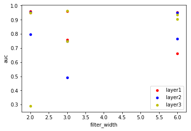

```python
corrs = pd.DataFrame(corrs, columns = ['conv layers','conv_filters', 'filter_width','nodes','parameters','auc'])
ax = plt.subplot(111)
cols = ['_','r','b','y']
for i in range(1,4):
    corrs[corrs['conv layers']==i].plot.scatter(x='filter_width', y='auc', ax=ax, color=cols[i], label='layer'+str(i))
corrs.sort_values('auc', ascending=False)
```

Why aren't convolutional models learning any more than dense models?

### Conclussions

- Asp and Glu are strongly correlated with TAD. Phe, Val, Ile and Leu also have impact on the label or score of a sequence. Arg is strongly negatively correlated with TAD
- Combining amino-acid frequencies in a linear model significantly improved both regression and classification performances.
- From all physicochemical properties tested, Charge show the strongest correlation with score/label. All other features have very poor predictive power.
- di-peptides might have a non-neglectible influence in the performance of predictive models.
- Dense Neural Networks (with ohe data) performs much better than linear and ensemble methods. **Why? Are they learning local distributions of these residues?**
- Convolutions (the way I am doing it) are not improving the performance. **why?**
- **interestingly** with only 2 layers of a single neuron or a single layer of 2 neurons the network can perform better than logistic regression. How simple should be the patter? Could it be that few 2-mers or so, diseminated throughout the sequence are being captured by the model?

#### Convolutional + Recurrent

this section can be skiped

```python
## in gizmo
'''from keras layers import LSTM

num_conv_layers, num_conv_filters = range(1,4), 2**np.arange(3)
filter_width, num_nodes = [3,6,9], 2**np.arange(1,4)
lstm_units = [3,6,9]

callback = EarlyStopping(patience=1)
params = [num_conv_layers, num_conv_filters, filter_width, num_nodes, lstm_units]
corrs = []
for ncl, ncf, fw, nnodes, lstmn in tqdm(itertools.product(*params)):
    K.clear_session()
    model.Sequential()
    model.add(Conv1D(ncf, fw, activation='relu', padding='same', input_shape=(30,20)))

    for l in range(ncl-1):
        model.add(Conv1D(ncf, fw, activation='relu', padding='same'))
        model.add(LSTM(lstmn))

    model.add(Flatten())
    model.add(Dense(nnodes, activation='relu'))
    model.add(Dense(1))

    model.compile(optimizer='rmsprop', loss='mse', metrics=['mse'])

    model.fit(Xtrain, regression[1], epochs=100, validation_split=0.1, callbacks=[callback], verbose=0)


    y_pred = model.predict(Xvalid)
    corr = spearmanr(y_pred, regression[5])[0]
    corrs.append([ncl, ncf, fw, nnodes, model.count_params(), corr])

corrs = np.array(corrs)'''
```

### Functions

```python
'''Split data into Train, Test and Validation sets with ratio 8:1:1'''
def split_data(idx=None, data=None, selection=aa, column_label_score_NAME='scores', seed=42):

    train, test = (np.array([0.8, 0.1]) * data.shape[0]).astype(int)

    X, y = data[selection].values, data[column_label_score_NAME].values
    X, y = X[idx], y[idx]

    Xtrain, ytrain = X[:train], y[:train]
    Xtest, ytest = X[train:-test], y[train:-test]
    Xvalid, yvalid = X[-test:], y[-test:]

    return(Xtrain, ytrain, Xtest, ytest, Xvalid, yvalid)

'''given X and y it outputs an array of thresholds, False positive rate and True positive rate'''
def roc_curve(X,y):
    # make sure X and y are numpy arrays
    X,y = np.array(X), np.array(y)
    # thresholds to use for defining fpr and tpr
    scale = np.linspace(X.min(), X.max(), 50)
    # define fpr and tpr functions to use with different thresholds
    def tpr(y_hat, y):
        a,b = set(np.hstack(np.where(y==1))), set(np.hstack(np.where(y_hat==1)))
        return(len(a & b) / len(a))
    def fpr(y_hat, y):
        a,b = set(np.hstack(np.where(y==0))), set(np.hstack(np.where(y_hat==1)))
        return(len(a & b) / len(a))
    # Core of the function where TPR and FPR are calculated
    TPR, FPR = np.zeros(50), np.zeros(50)
    for n,s in enumerate(scale):
        # threshold of variable defines what is + and -
        y_hat = np.array([1 if x>=s else 0 for x in X])
        TPR[n] = tpr(y_hat, y)
        FPR[n] = fpr(y_hat, y)
    # the resulting array will contain thresholds, fpr and tpr
    roc = np.vstack([scale, FPR, TPR])
    return(roc)

''' Open the new lukasz's files with sequences as index and two columns, scores and normalized scores'''
def open_fastas(ff):
    vals, keys = [], []
    fasta = open(ff)
    while True:
        try:
            header, sequence = next(fasta).strip(), next(fasta).strip()
            _, bg, b1, b2, b3, b4, score, norm_score = header.split("_")
            vals.append([score, norm_score])
            keys.append(sequence)
        except StopIteration: break
    df = pd.DataFrame(vals, index=keys, columns=['scores','norm_scores'])
    df = df.astype(float)
    return df
```

### Dense with 2-mers as features

I assume that the amino-acid frequencies should be included in the 2mers frequencies.

### 1 & 2 nodes dense models

```python
# go over the # of layers and nodes and see which is
# the # of parameters that gives the best correlation with real labels.

callback = EarlyStopping(patience=1)
num_layers, num_nodes = range(1,6), [1,2]

corrs = []

for nlayers, nnodes in tqdm(itertools.product(num_layers, num_nodes)):
    np.random.seed=0

    K.clear_session()
    model = Sequential()
    model.add(Dense(nnodes, activation='relu', input_shape=(600,)))

    for i in range(nlayers-1):
        model.add(Dense(nnodes, activation='relu'))

    model.add(Dense(1))
    model.compile(optimizer='adam', loss='binary_crossentropy', metrics=['accuracy'])
    model.fit(classification[0], classification[1],
              epochs=100,
              validation_split=0.1,
              callbacks=[callback],
              verbose=0)

    y_pred = model.predict(classification[4])
    _, fpr, tpr = roc_curve(y_pred, classification[5])
    corrs.append([nlayers, nnodes, model.count_params(), auc(fpr, tpr)])
    #corrs.append([nlayers, nnodes, model.count_params(), spearmanr(y_pred, regression[5])])

corrs = np.array(corrs);
```

```
10it [01:12,  7.20s/it]
```

|  | layers | nodes | parameters | auc |
| --- | --- | --- | --- | --- |
| 2 | 2.0 | 1.0 | 605.0 | 0.961937 |
| 1 | 1.0 | 2.0 | 1205.0 | 0.961565 |
| 7 | 4.0 | 2.0 | 1223.0 | 0.961064 |
| 9 | 5.0 | 2.0 | 1229.0 | 0.957746 |
| 0 | 1.0 | 1.0 | 603.0 | 0.432974 |
| 3 | 2.0 | 2.0 | 1211.0 | 0.328652 |
| 4 | 3.0 | 1.0 | 607.0 | 0.000000 |
| 5 | 3.0 | 2.0 | 1217.0 | 0.000000 |
| 6 | 4.0 | 1.0 | 609.0 | 0.000000 |
| 8 | 5.0 | 1.0 | 611.0 | 0.000000 |

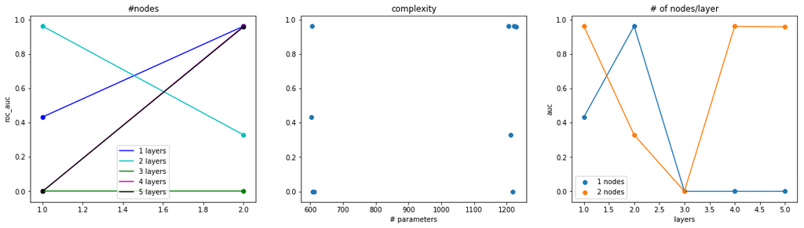

```python
plt.figure(figsize=(20,5))
colors = ['r','b','c','g','m','k']
def P(x,y, i):
    plt.scatter(x, y, c=colors[i])
    plt.plot(x, y, label=str(i)+' layers', c=colors[i])
    plt.legend()


plt.subplot(131)
plt.title('#nodes')
for i in range(1,6):
    tmp = corrs[corrs[:,0]==i]
    P(tmp[:,1], tmp[:,3], i)
plt.ylabel('roc_auc')

plt.subplot(132)
plt.title('complexity')
plt.scatter(corrs[:,2], corrs[:,3])
plt.xlabel('# parameters')

plt.subplot(133)
plt.title('# of nodes/layer')
for i in [1,2]:
    tmp = corrs[corrs[:,1]==i]
    plt.scatter(tmp[:,0], tmp[:,3], label=str(i)+' nodes')
    plt.plot(tmp[:,0], tmp[:,3])
plt.legend()
plt.xlabel('layers')
plt.ylabel('auc');


pd.DataFrame(corrs, columns=['layers','nodes','parameters','auc']).sort_values('auc', ascending=False)
```